# Covid Research

## Import Data

```r
#Covid-19 Info
cov_general_data<- read_csv2("../datasets/COVID-19_aantallen_gemeente_per_dag.csv")
```

```
## i Using "','" as decimal and "'.'" as grouping mark. Use `read_delim()` for more control.
```

```r
cov_hospital_data <- read_csv2("../datasets/COVID-19_ziekenhuisopnames.csv")
```

```
## i Using "','" as decimal and "'.'" as grouping mark. Use `read_delim()` for more control.
```

```r
cov_performed_tests <- read_csv2("../datasets/COVID-19_uitgevoerde_testen.csv")
```

```
## i Using "','" as decimal and "'.'" as grouping mark. Use `read_delim()` for more control.
```

```r
#Other info
res_count_per_province_nl <- read_csv2("../datasets/Bevolkings_aantallen_per_provincie.csv")
```

```
## i Using "','" as decimal and "'.'" as grouping mark. Use `read_delim()` for more control.
```

## Exploring

Population per province compared to the positive tests, hospital admissions and deaths per province

## Lets first inspect the datasets

```r
head(cov_general_data)
```

```
## # A tibble: 6 x 12
##   Version Date_of_report      Date_of_publica~ Municipality_co~ Municipality_na~
##     <dbl> <dttm>              <date>           <chr>            <chr>
## 1       5 2022-03-30 10:00:00 2020-02-28       GM0014           Groningen
## 2       5 2022-03-30 10:00:00 2020-02-28       GM0034           Almere
## 3       5 2022-03-30 10:00:00 2020-02-28       GM0037           Stadskanaal
## 4       5 2022-03-30 10:00:00 2020-02-28       GM0047           Veendam
## 5       5 2022-03-30 10:00:00 2020-02-28       GM0050           Zeewolde
## 6       5 2022-03-30 10:00:00 2020-02-28       GM0059           Achtkarspelen
## # ... with 7 more variables: Province <chr>, Security_region_code <chr>,
## #   Security_region_name <chr>, Municipal_health_service <chr>,
## #   ROAZ_region <chr>, Total_reported <dbl>, Deceased <dbl>
```

```r
head(cov_hospital_data)
```

```
## # A tibble: 6 x 9
##   Version Date_of_report      Date_of_statist~ Municipality_co~ Municipality_na~
##     <dbl> <dttm>              <date>           <chr>            <chr>
## 1       3 2022-03-30 00:30:00 2020-02-27       GM0014           Groningen
## 2       3 2022-03-30 00:30:00 2020-02-27       GM0034           Almere
## 3       3 2022-03-30 00:30:00 2020-02-27       GM0037           Stadskanaal
## 4       3 2022-03-30 00:30:00 2020-02-27       GM0047           Veendam
## 5       3 2022-03-30 00:30:00 2020-02-27       GM0050           Zeewolde
## 6       3 2022-03-30 00:30:00 2020-02-27       GM0059           Achtkarspelen
## # ... with 4 more variables: Security_region_code <chr>,
## #   Security_region_name <chr>, Hospital_admission_notification <dbl>,
## #   Hospital_admission <dbl>
```

```r
head(res_count_per_province_nl)
```

```
## # A tibble: 6 x 3
##   `Regio's`       Perioden  aantal
##   <chr>              <dbl>   <dbl>
## 1 Groningen (PV)      2021  586937
## 2 Fryslân (PV)        2021  651435
## 3 Drenthe (PV)        2021  494771
## 4 Overijssel (PV)     2021 1166533
## 5 Flevoland (PV)      2021  428226
## 6 Gelderland (PV)     2021 2096603
```

```r
head(cov_performed_tests)
```

```
## # A tibble: 6 x 7
##   Version Date_of_report      Date_of_statist~ Security_region~ Security_region~
##     <dbl> <dttm>              <date>           <chr>            <chr>
## 1       2 2022-03-30 09:00:00 2020-06-01       VR01             Groningen
## 2       2 2022-03-30 09:00:00 2020-06-02       VR01             Groningen
## 3       2 2022-03-30 09:00:00 2020-06-03       VR01             Groningen
## 4       2 2022-03-30 09:00:00 2020-06-04       VR01             Groningen
## 5       2 2022-03-30 09:00:00 2020-06-05       VR01             Groningen
## 6       2 2022-03-30 09:00:00 2020-06-06       VR01             Groningen
## # ... with 2 more variables: Tested_with_result <dbl>, Tested_positive <dbl>
```

# Cleaning, mutating and filtering data (LG 1)

## Filter out the null values from cov_general_data where the province is null since we cant use those in our research

### Making a new cleaned tibble called cov_general_data_clean

```r
cov_general_data_clean <- filter(cov_general_data,!is.na(Province))
head(cov_general_data_clean)
```

```
## # A tibble: 6 x 12
##   Version Date_of_report      Date_of_publica~ Municipality_co~ Municipality_na~
##     <dbl> <dttm>              <date>           <chr>            <chr>
## 1       5 2022-03-30 10:00:00 2020-02-28       GM0014           Groningen
## 2       5 2022-03-30 10:00:00 2020-02-28       GM0034           Almere
## 3       5 2022-03-30 10:00:00 2020-02-28       GM0037           Stadskanaal
## 4       5 2022-03-30 10:00:00 2020-02-28       GM0047           Veendam
## 5       5 2022-03-30 10:00:00 2020-02-28       GM0050           Zeewolde
## 6       5 2022-03-30 10:00:00 2020-02-28       GM0059           Achtkarspelen
## # ... with 7 more variables: Province <chr>, Security_region_code <chr>,
## #   Security_region_name <chr>, Municipal_health_service <chr>,
## #   ROAZ_region <chr>, Total_reported <dbl>, Deceased <dbl>
```

## Two names of provinces have been detected and we will use “Friesland” for the sake of consistency

```r
cov_general_data_clean <- cov_general_data_clean %>%
  mutate(Province = replace(Province, Province == "Fryslân", "Friesland"))
head(cov_general_data_clean)
```

```
## # A tibble: 6 x 12
##   Version Date_of_report      Date_of_publica~ Municipality_co~ Municipality_na~
##     <dbl> <dttm>              <date>           <chr>            <chr>
## 1       5 2022-03-30 10:00:00 2020-02-28       GM0014           Groningen
## 2       5 2022-03-30 10:00:00 2020-02-28       GM0034           Almere
## 3       5 2022-03-30 10:00:00 2020-02-28       GM0037           Stadskanaal
## 4       5 2022-03-30 10:00:00 2020-02-28       GM0047           Veendam
## 5       5 2022-03-30 10:00:00 2020-02-28       GM0050           Zeewolde
## 6       5 2022-03-30 10:00:00 2020-02-28       GM0059           Achtkarspelen
## # ... with 7 more variables: Province <chr>, Security_region_code <chr>,
## #   Security_region_name <chr>, Municipal_health_service <chr>,
## #   ROAZ_region <chr>, Total_reported <dbl>, Deceased <dbl>
```

## Remove variables that we are not going to use from cov_general_data_clean

```r
cov_general_data_clean$Security_region_code <- NULL
cov_general_data_clean$Security_region_name <- NULL
cov_general_data_clean$Version <- NULL
cov_general_data_clean$Municipal_health_service <- NULL
cov_general_data_clean$ROAZ_region <- NULL
cov_general_data_clean$Municipality_code <- NULL
cov_general_data_clean$Municipality_name <- NULL

head(cov_general_data_clean)
```

```
## # A tibble: 6 x 5
##   Date_of_report      Date_of_publication Province  Total_reported Deceased
##   <dttm>              <date>              <chr>              <dbl>    <dbl>
## 1 2022-03-30 10:00:00 2020-02-28          Groningen              0        0
## 2 2022-03-30 10:00:00 2020-02-28          Flevoland              0        0
## 3 2022-03-30 10:00:00 2020-02-28          Groningen              0        0
## 4 2022-03-30 10:00:00 2020-02-28          Groningen              0        0
## 5 2022-03-30 10:00:00 2020-02-28          Flevoland              0        0
## 6 2022-03-30 10:00:00 2020-02-28          Friesland              0        0
```

## Filter null values out of the dataset cov_hospital_data

### Making a new cleaned tibble called cov_hospital_data_clean

```r
cov_hospital_data_clean <- filter(cov_hospital_data, !is.na(Security_region_name))
head(cov_hospital_data_clean)
```

```
## # A tibble: 6 x 9
##   Version Date_of_report      Date_of_statist~ Municipality_co~ Municipality_na~
##     <dbl> <dttm>              <date>           <chr>            <chr>
## 1       3 2022-03-30 00:30:00 2020-02-27       GM0014           Groningen
## 2       3 2022-03-30 00:30:00 2020-02-27       GM0034           Almere
## 3       3 2022-03-30 00:30:00 2020-02-27       GM0037           Stadskanaal
## 4       3 2022-03-30 00:30:00 2020-02-27       GM0047           Veendam
## 5       3 2022-03-30 00:30:00 2020-02-27       GM0050           Zeewolde
## 6       3 2022-03-30 00:30:00 2020-02-27       GM0059           Achtkarspelen
## # ... with 4 more variables: Security_region_code <chr>,
## #   Security_region_name <chr>, Hospital_admission_notification <dbl>,
## #   Hospital_admission <dbl>
```

## Rename ‘Fryslân’ to ‘Friesland’ in cov_hospital_data_clean

```r
cov_hospital_data_clean <- cov_hospital_data_clean %>%
  mutate(Security_region_name = replace(Security_region_name, Security_region_name == "Fryslân", "Friesland"))
head(cov_hospital_data_clean)
```

```
## # A tibble: 6 x 9
##   Version Date_of_report      Date_of_statist~ Municipality_co~ Municipality_na~
##     <dbl> <dttm>              <date>           <chr>            <chr>
## 1       3 2022-03-30 00:30:00 2020-02-27       GM0014           Groningen
## 2       3 2022-03-30 00:30:00 2020-02-27       GM0034           Almere
## 3       3 2022-03-30 00:30:00 2020-02-27       GM0037           Stadskanaal
## 4       3 2022-03-30 00:30:00 2020-02-27       GM0047           Veendam
## 5       3 2022-03-30 00:30:00 2020-02-27       GM0050           Zeewolde
## 6       3 2022-03-30 00:30:00 2020-02-27       GM0059           Achtkarspelen
## # ... with 4 more variables: Security_region_code <chr>,
## #   Security_region_name <chr>, Hospital_admission_notification <dbl>,
## #   Hospital_admission <dbl>
```

## Combine security regions into their respective provinces to a province variable to better fit the resident count data for later.

### Sorted based off this article wiki https://en.wikipedia.org/wiki/Safety_region

### Only the provinces Overijssel, Gelderland, Noord/Zuid-Holland, Noord-Brabant and Limburg are fragmented the others are fine

```r
overijssel_vr <- c("VR04","VR05")
gelderland_vr <- c("VR06","VR07","VR08")
north_holland_vr <- c("VR10","VR11","VR12","VR13","VR14")
south_holland_vr <- c("VR15","VR16","VR17","VR18")
north_brabant_vr <- c("VR20","VR21","VR22")
limburg_vr <- c("VR23","VR24")

cov_hospital_data_clean <- cov_hospital_data_clean %>%
  mutate(Province = case_when(
    Security_region_code %in% overijssel_vr ~ 'Overijssel',
    Security_region_code %in% gelderland_vr ~ 'Gelderland',
    Security_region_code %in% north_holland_vr ~ 'Noord-Holland',
    Security_region_code %in% south_holland_vr ~ 'Zuid-Holland',
    Security_region_code %in% north_brabant_vr ~ 'Noord-Brabant',
    Security_region_code %in% limburg_vr ~ 'Limburg',
    TRUE ~ Security_region_name))

head(cov_hospital_data_clean)
```

```
## # A tibble: 6 x 10
##   Version Date_of_report      Date_of_statist~ Municipality_co~ Municipality_na~
##     <dbl> <dttm>              <date>           <chr>            <chr>
## 1       3 2022-03-30 00:30:00 2020-02-27       GM0014           Groningen
## 2       3 2022-03-30 00:30:00 2020-02-27       GM0034           Almere
## 3       3 2022-03-30 00:30:00 2020-02-27       GM0037           Stadskanaal
## 4       3 2022-03-30 00:30:00 2020-02-27       GM0047           Veendam
## 5       3 2022-03-30 00:30:00 2020-02-27       GM0050           Zeewolde
## 6       3 2022-03-30 00:30:00 2020-02-27       GM0059           Achtkarspelen
## # ... with 5 more variables: Security_region_code <chr>,
## #   Security_region_name <chr>, Hospital_admission_notification <dbl>,
## #   Hospital_admission <dbl>, Province <chr>
```

## Remove variables that we are not going to use from cov_hospital_data_clean

```r
cov_hospital_data_clean$Municipality_name <- NULL
cov_hospital_data_clean$Municipality_code <- NULL
cov_hospital_data_clean$Security_region_code <- NULL
cov_hospital_data_clean$Security_region_name <- NULL

head(cov_hospital_data_clean)
```

```
## # A tibble: 6 x 6
##   Version Date_of_report      Date_of_statist~ Hospital_admiss~ Hospital_admiss~
##     <dbl> <dttm>              <date>                      <dbl>            <dbl>
## 1       3 2022-03-30 00:30:00 2020-02-27                      0                0
## 2       3 2022-03-30 00:30:00 2020-02-27                      0                0
## 3       3 2022-03-30 00:30:00 2020-02-27                      0                0
## 4       3 2022-03-30 00:30:00 2020-02-27                      0                0
## 5       3 2022-03-30 00:30:00 2020-02-27                      0                0
## 6       3 2022-03-30 00:30:00 2020-02-27                      0                0
## # ... with 1 more variable: Province <chr>
```

## Remove the pv tag from province

### First rename the names to English

```r
names(res_count_per_province_nl)[1] <- "Province"
names(res_count_per_province_nl)[2] <- "Period"
names(res_count_per_province_nl)[3] <- "Amount"

## Remove the (PV) tag from province
res_count_per_province_nl$Province = gsub('.{5}$', '', res_count_per_province_nl$Province)

## renaming for consistency
res_count_per_province_nl <- res_count_per_province_nl %>%
  mutate(Province = replace(Province, Province == "Fryslân", "Friesland"))

head(res_count_per_province_nl)
```

```
## # A tibble: 6 x 3
##   Province   Period  Amount
##   <chr>       <dbl>   <dbl>
## 1 Groningen    2021  586937
## 2 Friesland    2021  651435
## 3 Drenthe      2021  494771
## 4 Overijssel   2021 1166533
## 5 Flevoland    2021  428226
## 6 Gelderland   2021 2096603
```

## Rename ‘Fryslân’ to ‘Friesland’ in cov_performed_tests_clean

```r
cov_performed_tests_clean <- cov_performed_tests %>%
  mutate(Security_region_name = replace(Security_region_name, Security_region_name == "Fryslân", "Friesland"))

head(cov_performed_tests_clean)
```

```
## # A tibble: 6 x 7
##   Version Date_of_report      Date_of_statist~ Security_region~ Security_region~
##     <dbl> <dttm>              <date>           <chr>            <chr>
## 1       2 2022-03-30 09:00:00 2020-06-01       VR01             Groningen
## 2       2 2022-03-30 09:00:00 2020-06-02       VR01             Groningen
## 3       2 2022-03-30 09:00:00 2020-06-03       VR01             Groningen
## 4       2 2022-03-30 09:00:00 2020-06-04       VR01             Groningen
## 5       2 2022-03-30 09:00:00 2020-06-05       VR01             Groningen
## 6       2 2022-03-30 09:00:00 2020-06-06       VR01             Groningen
## # ... with 2 more variables: Tested_with_result <dbl>, Tested_positive <dbl>
```

## Filter the dataset cov_performed_tests_clean to also group security regions

```r
cov_performed_tests_clean <- cov_performed_tests_clean %>%
  mutate(Province = case_when(
    Security_region_code %in% overijssel_vr ~ 'Overijssel',
    Security_region_code %in% gelderland_vr ~ 'Gelderland',
    Security_region_code %in% north_holland_vr ~ 'Noord-Holland',
    Security_region_code %in% south_holland_vr ~ 'Zuid-Holland',
    Security_region_code %in% north_brabant_vr ~ 'Noord-Brabant',
    Security_region_code %in% limburg_vr ~ 'Limburg',
    TRUE ~ Security_region_name))

head(cov_performed_tests_clean)
```

```
## # A tibble: 6 x 8
##   Version Date_of_report      Date_of_statist~ Security_region~ Security_region~
##     <dbl> <dttm>              <date>           <chr>            <chr>
## 1       2 2022-03-30 09:00:00 2020-06-01       VR01             Groningen
## 2       2 2022-03-30 09:00:00 2020-06-02       VR01             Groningen
## 3       2 2022-03-30 09:00:00 2020-06-03       VR01             Groningen
## 4       2 2022-03-30 09:00:00 2020-06-04       VR01             Groningen
## 5       2 2022-03-30 09:00:00 2020-06-05       VR01             Groningen
## 6       2 2022-03-30 09:00:00 2020-06-06       VR01             Groningen
## # ... with 3 more variables: Tested_with_result <dbl>, Tested_positive <dbl>,
## #   Province <chr>
```

## Remove unused variables from the cov_performed_tests_clean dataset

```r
cov_performed_tests_clean$Security_region_code <- NULL
cov_performed_tests_clean$Security_region_name <- NULL

head(cov_performed_tests_clean)
```

```
## # A tibble: 6 x 6
##   Version Date_of_report      Date_of_statisti~ Tested_with_res~ Tested_positive
##     <dbl> <dttm>              <date>                       <dbl>           <dbl>
## 1       2 2022-03-30 09:00:00 2020-06-01                       3               0
## 2       2 2022-03-30 09:00:00 2020-06-02                     210               0
## 3       2 2022-03-30 09:00:00 2020-06-03                     209               0
## 4       2 2022-03-30 09:00:00 2020-06-04                     245               1
## 5       2 2022-03-30 09:00:00 2020-06-05                     227               0
## 6       2 2022-03-30 09:00:00 2020-06-06                     100               0
## # ... with 1 more variable: Province <chr>
```

## Calculate the cumulative sum of all performed tests and positive tests per date

```r
cov_performed_tests_clean <- cov_performed_tests_clean %>%
  group_by(Date_of_statistics) %>%
  mutate(Total_tested_with_result = cumsum(Tested_with_result)) %>%
  mutate(Total_tested_positive = cumsum(Tested_positive))

head(cov_performed_tests_clean)
```

```
## # A tibble: 6 x 8
## # Groups:   Date_of_statistics [6]
##   Version Date_of_report      Date_of_statisti~ Tested_with_res~ Tested_positive
##     <dbl> <dttm>              <date>                       <dbl>           <dbl>
## 1       2 2022-03-30 09:00:00 2020-06-01                       3               0
## 2       2 2022-03-30 09:00:00 2020-06-02                     210               0
## 3       2 2022-03-30 09:00:00 2020-06-03                     209               0
## 4       2 2022-03-30 09:00:00 2020-06-04                     245               1
## 5       2 2022-03-30 09:00:00 2020-06-05                     227               0
## 6       2 2022-03-30 09:00:00 2020-06-06                     100               0
## # ... with 3 more variables: Province <chr>, Total_tested_with_result <dbl>,
## #   Total_tested_positive <dbl>
```

## Aggregate the Total_tested_with_result and Total_tested_positive to eventually get the total over time

```r
total_cov_tests_by_date <- aggregate(cov_performed_tests_clean$Total_tested_with_result, list(cov_performed_tests_clean$Date_of_statistics), max)
head(total_cov_tests_by_date)
```

```
##      Group.1    x
## 1 2020-06-01 1551
## 2 2020-06-02 6821
## 3 2020-06-03 8880
## 4 2020-06-04 9352
## 5 2020-06-05 9478
## 6 2020-06-06 7852
```

```r
total_pos_cov_tests_by_date <- aggregate(cov_performed_tests_clean$Total_tested_positive, list(cov_performed_tests_clean$Date_of_statistics), max)
head(total_pos_cov_tests_by_date)
```

```
##      Group.1   x
## 1 2020-06-01  73
## 2 2020-06-02 203
## 3 2020-06-03 165
## 4 2020-06-04 173
## 5 2020-06-05 135
## 6 2020-06-06 125
```

## Rename columms from the datasets “total_cov_tests_by_date” and “total_pos_cov_tests_by_date”

```r
names(total_cov_tests_by_date)[1] <- "Date_of_report"
names(total_cov_tests_by_date)[2] <- "Tests_done"
names(total_pos_cov_tests_by_date)[1] <- "Date_of_report"
names(total_pos_cov_tests_by_date)[2] <- "Positive_tests"

head(total_cov_tests_by_date)
```

```
##   Date_of_report Tests_done
## 1     2020-06-01       1551
## 2     2020-06-02       6821
## 3     2020-06-03       8880
## 4     2020-06-04       9352
## 5     2020-06-05       9478
## 6     2020-06-06       7852
```

```r
head(total_pos_cov_tests_by_date)
```

```
##   Date_of_report Positive_tests
## 1     2020-06-01             73
## 2     2020-06-02            203
## 3     2020-06-03            165
## 4     2020-06-04            173
## 5     2020-06-05            135
## 6     2020-06-06            125
```

## Combine the results one last time in seperate tables

```r
total_cov_tests_by_date <- total_cov_tests_by_date %>%
  mutate(Total_tests_over_time = cumsum(Tests_done))

head(total_cov_tests_by_date)
```

```
##   Date_of_report Tests_done Total_tests_over_time
## 1     2020-06-01       1551                  1551
## 2     2020-06-02       6821                  8372
## 3     2020-06-03       8880                 17252
## 4     2020-06-04       9352                 26604
## 5     2020-06-05       9478                 36082
## 6     2020-06-06       7852                 43934
```

```r
total_pos_cov_tests_by_date <- total_pos_cov_tests_by_date %>%
  mutate(Total_positive_tests_over_time = cumsum(Positive_tests))

head(total_pos_cov_tests_by_date)
```

```
##   Date_of_report Positive_tests Total_positive_tests_over_time
## 1     2020-06-01             73                             73
## 2     2020-06-02            203                            276
## 3     2020-06-03            165                            441
## 4     2020-06-04            173                            614
## 5     2020-06-05            135                            749
## 6     2020-06-06            125                            874
```

## Combine to one table by date

```r
total_test_results_by_date <- merge(total_cov_tests_by_date, total_pos_cov_tests_by_date)

head(total_test_results_by_date)
```

```
##   Date_of_report Tests_done Total_tests_over_time Positive_tests
## 1     2020-06-01       1551                  1551             73
## 2     2020-06-02       6821                  8372            203
## 3     2020-06-03       8880                 17252            165
## 4     2020-06-04       9352                 26604            173
## 5     2020-06-05       9478                 36082            135
## 6     2020-06-06       7852                 43934            125
##   Total_positive_tests_over_time
## 1                             73
## 2                            276
## 3                            441
## 4                            614
## 5                            749
## 6                            874
```

## Create merged dataset called merged_res_count_general_data

### 1. Add population numbers to the correct province in the performed tests dataset

### 2. Remove not needed variables, in this case the Period variable

### 3. Rename population amount variable

### 4. Set duplicates to 0 for to make it easier to plot

```r
# 1
merged_res_count_general_data <- merge(cov_performed_tests_clean, res_count_per_province_nl, by= c("Province", "Province"))

# 2
merged_res_count_general_data$Period <- NULL

# 3
merged_res_count_general_data <- merged_res_count_general_data %>%
  rename( Resident_count = Amount)

# 4
merged_res_count_general_data$Resident_count[duplicated(merged_res_count_general_data$Resident_count)] <- 0
```

# Transforming and providing analysis on the data (LG 2)

## Positive tests from The Netherlands over time

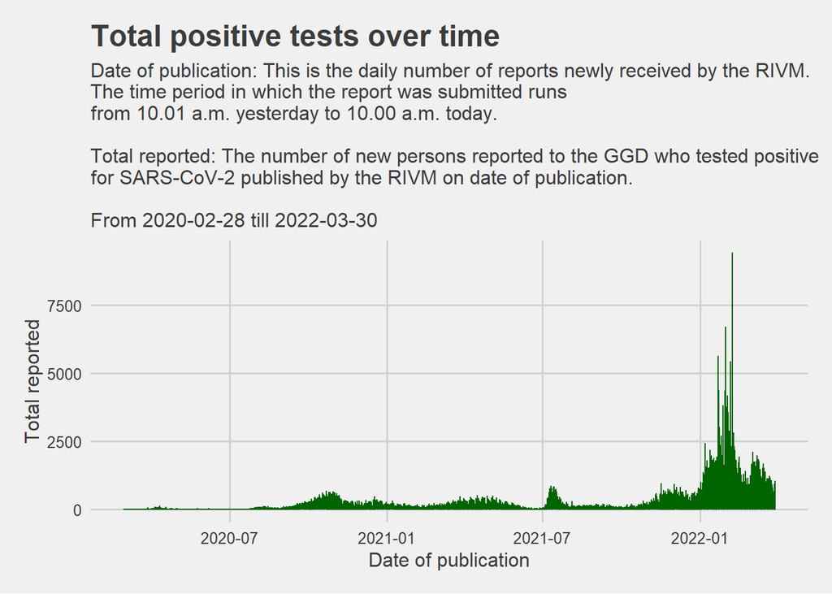

```r
cov_general_data_clean %>% ggplot(aes(x = Date_of_publication, y = Total_reported)) +
  geom_line(color = "darkgreen") +
  labs(title = "Total positive tests over time",
       subtitle = "Date of publication: This is the daily number of reports newly received by the RIVM.\nThe time period in which the report was submitted runs\nfrom 10.01 a.m. yesterday to 10.00 a.m. today.\n\nTotal reported: The number of new persons reported to the GGD who tested positive \nfor SARS-CoV-2 published by the RIVM on date of publication.\n\nFrom 2020-02-28 till 2022-03-30",
       y = "Total reported",
       x = "Date of publication") +
  theme_fivethirtyeight() +
  theme(axis.title = element_text())
```

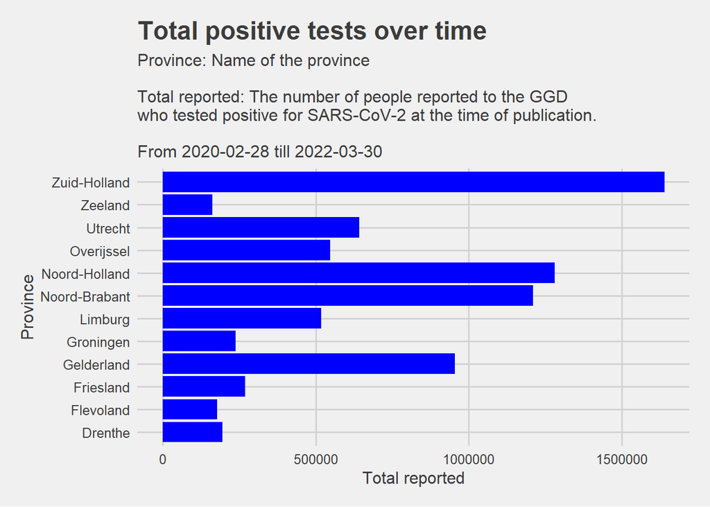

```r
cov_general_data_clean %>% ggplot(aes(x = Province, y = Total_reported)) +
  geom_bar(stat = "identity", fill = "blue") + coord_flip() +
  labs(title = "Total positive tests over time",
       subtitle = "Province: Name of the province\n\nTotal reported: The number of people reported to the GGD \nwho tested positive for SARS-CoV-2 at the time of publication.\n\nFrom 2020-02-28 till 2022-03-30",
       y = "Total reported",
       x = "Province") +
  theme_fivethirtyeight() +
  theme(axis.title = element_text())
```

## Hospital admissions from The Netherlands over time

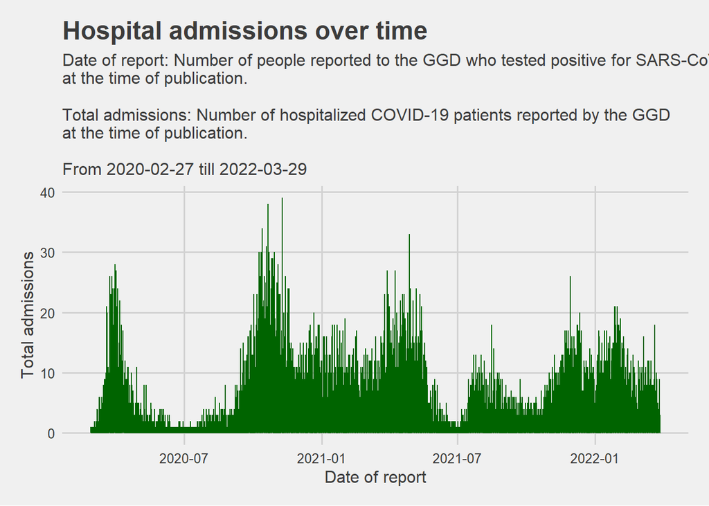

```r
cov_hospital_data_clean %>% ggplot(aes(x = Date_of_statistics, y = Hospital_admission)) +
  geom_line(color = "darkgreen") +
  labs(title = "Hospital admissions over time",
       subtitle = "Date of report: Number of people reported to the GGD who tested positive for SARS-CoV-2 \nat the time of publication.\n\nTotal admissions: Number of hospitalized COVID-19 patients reported by the GGD \nat the time of publication.\n\nFrom 2020-02-27 till 2022-03-29",
       y = "Total admissions",
       x = "Date of report") +
  theme_fivethirtyeight() +
  theme(axis.title = element_text())
```

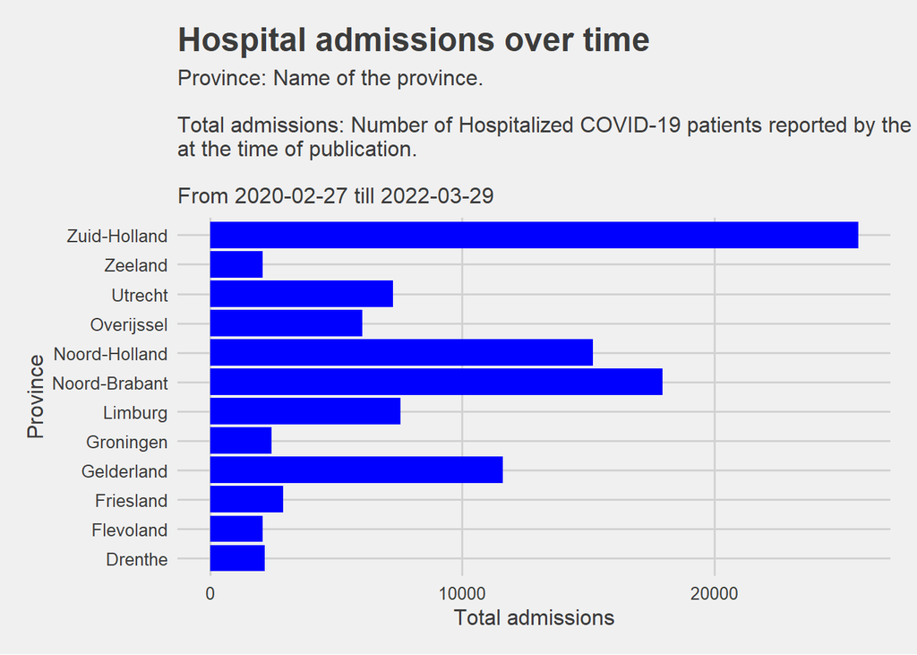

```r
cov_hospital_data_clean %>% ggplot(aes(x = Province, y = Hospital_admission)) +
  geom_bar(stat = "identity", fill = "blue") + coord_flip() +
  labs(title = "Hospital admissions over time",
       subtitle = "Province: Name of the province.\n\nTotal admissions: Number of Hospitalized COVID-19 patients reported by the GGD \nat the time of publication.\n\nFrom 2020-02-27 till 2022-03-29",
       y = "Total admissions",
       x = "Province") +
  theme_fivethirtyeight() +
  theme(axis.title = element_text())
```

## Deceased from The Netherlands over time

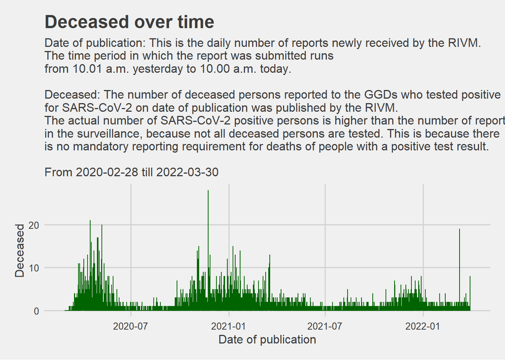

```r
cov_general_data_clean %>% ggplot(aes(x = Date_of_publication, y = Deceased)) +
  geom_line(color = "darkgreen") +
  labs(title = "Deceased over time",
       subtitle = "Date of publication: This is the daily number of reports newly received by the RIVM.\nThe time period in which the report was submitted runs\nfrom 10.01 a.m. yesterday to 10.00 a.m. today.\n\nDeceased: The number of deceased persons reported to the GGDs who tested positive \nfor SARS-CoV-2 on date of publication was published by the RIVM. \nThe actual number of SARS-CoV-2 positive persons is higher than the number of reports \nin the surveillance, because not all deceased persons are tested. This is because there \nis no mandatory reporting requirement for deaths of people with a positive test result.\n\nFrom 2020-02-28 till 2022-03-30",
       y = "Deceased",
       x = "Date of publication") +
  theme_fivethirtyeight() +
  theme(axis.title = element_text())
```

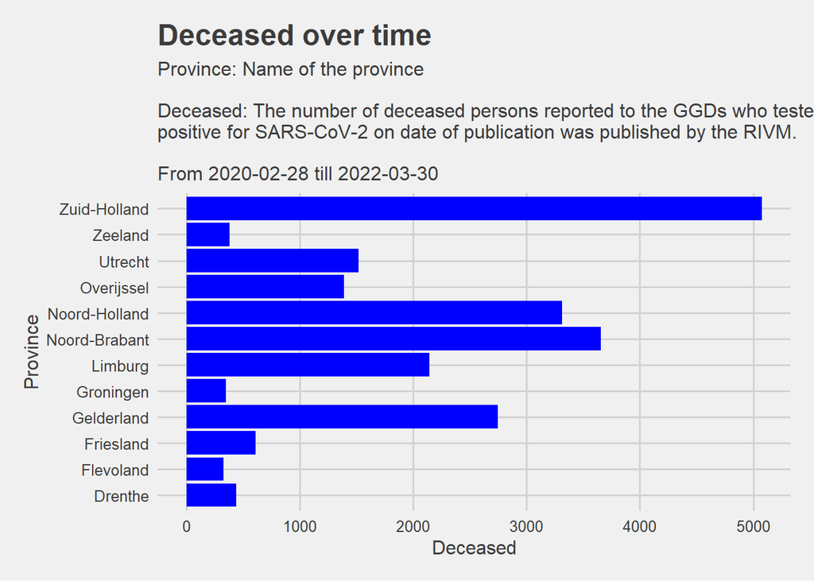

```r
cov_general_data_clean %>% ggplot(aes(x = Province, y = Deceased)) +
  geom_bar(stat = "identity", fill = "blue") + coord_flip() +
  labs(title = "Deceased over time",
       subtitle = "Province: Name of the province\n\nDeceased: The number of deceased persons reported to the GGDs who tested \npositive for SARS-CoV-2 on date of publication was published by the RIVM.\n\nFrom 2020-02-28 till 2022-03-30",
       y = "Deceased",
       x = "Province") +
  theme_fivethirtyeight() +
  theme(axis.title = element_text())
```

## Total performed tests from The Netherlands over time

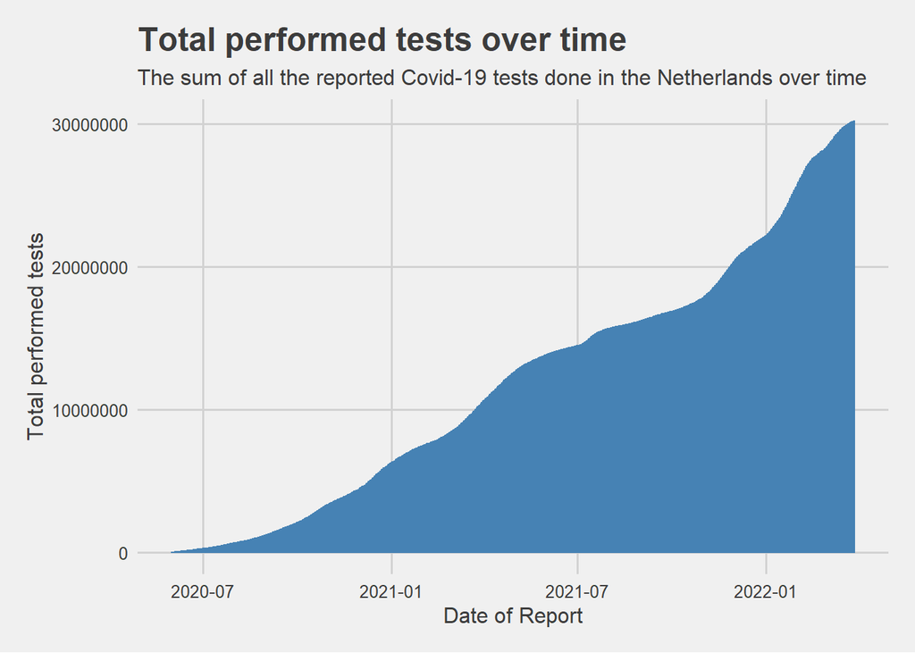

```r
total_cov_tests_by_date %>% ggplot(aes(x = Date_of_report, y = Total_tests_over_time)) +
  geom_col(color = "steelblue") +
  labs(title = "Total performed tests over time",
       subtitle = "The sum of all the reported Covid-19 tests done in the Netherlands over time",
       y = "Total performed tests",
       x = "Date of Report") +
  theme_fivethirtyeight() +
  theme(axis.title = element_text())
```

## Total performed tests and positive tests from The Netherlands over time

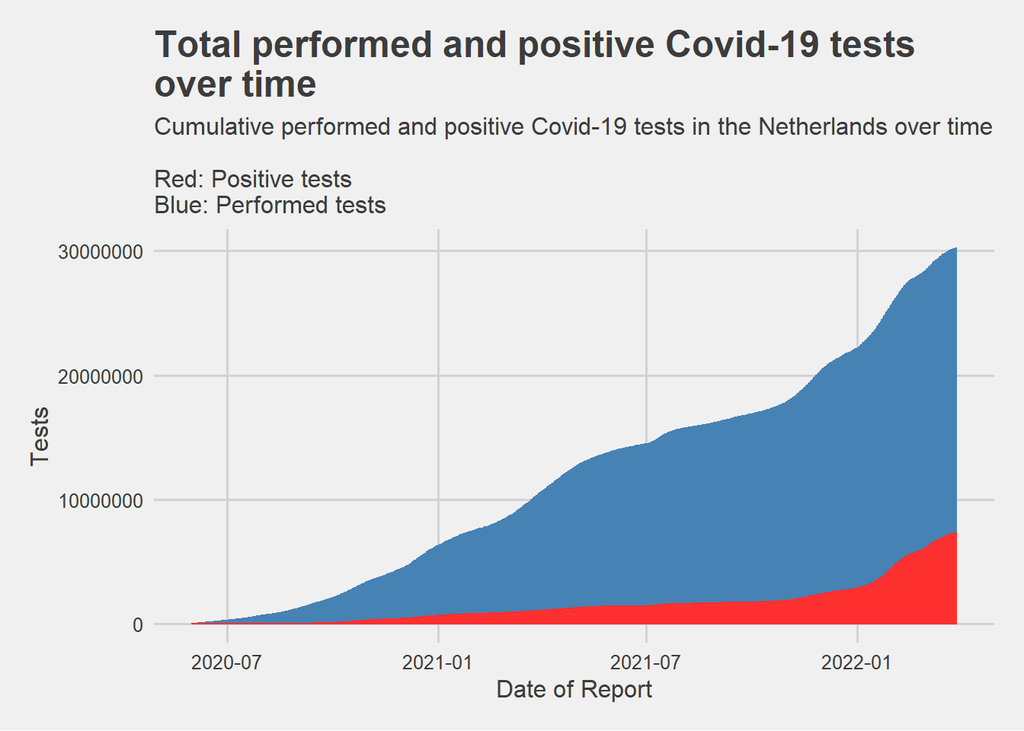

```r
total_test_results_by_date %>% ggplot(aes(x = Date_of_report)) +
  geom_col(aes(y = Total_tests_over_time), color= "steelblue") +
  geom_col(aes(y = Total_positive_tests_over_time), color= "firebrick1") +
  labs(title = "Total performed and positive Covid-19 tests\nover time",
       subtitle = "Cumulative performed and positive Covid-19 tests in the Netherlands over time\n\nRed: Positive tests\nBlue: Performed tests",
       x = "Date of Report",
       y = "Tests") +
  theme_fivethirtyeight() +
  theme(axis.title = element_text())
```

## Total performed tests compared to population per province

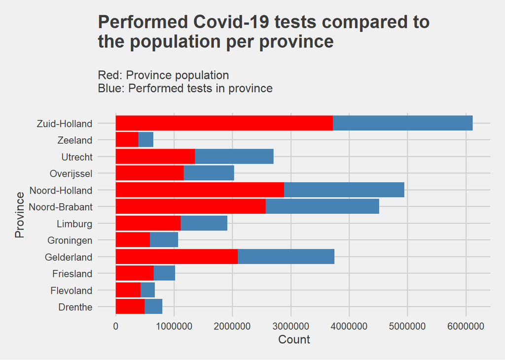

```r
ggplot(data = merged_res_count_general_data, aes(x = Province)) +
  geom_bar(aes(y = Tested_with_result), stat = 'identity', fill = 'steelblue') +
  geom_bar(aes(y = Resident_count), stat = 'identity', fill = 'red') +
  coord_flip() +
  labs(title = "Performed Covid-19 tests compared to \nthe population per province",
       subtitle = "\nRed: Province population\nBlue: Performed tests in province\n",
       y = "Count",
       x = "Province") +
  scale_y_continuous(n.breaks = 6) +
  theme_fivethirtyeight() +
  theme(axis.title = element_text())
```

## Total performed tests and positive tests compared to population per province

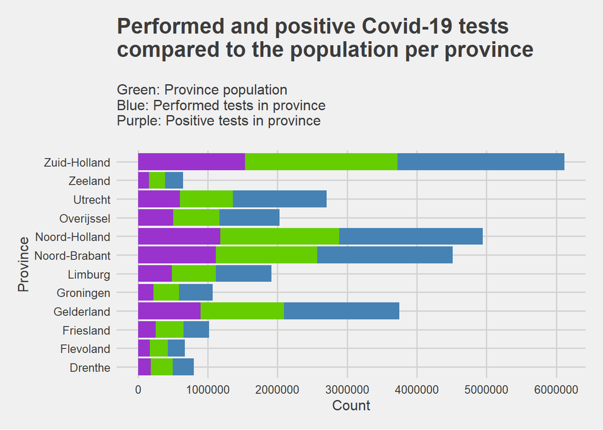

```r
ggplot(data = merged_res_count_general_data, aes(x = Province)) +
  geom_bar(aes(y = Tested_with_result), stat = 'identity', fill = 'steelblue') +
  geom_bar(aes(y = Resident_count), stat = 'identity', fill = 'chartreuse3') +
  geom_bar(aes(y = Tested_positive), stat = 'identity', fill = 'darkorchid3') +
  coord_flip() +
  labs(title = "Performed and positive Covid-19 tests\ncompared to the population per province",
       subtitle = "\nGreen: Province population\nBlue: Performed tests in province\nPurple: Positive tests in province\n",
       y = "Count",
       x = "Province") +
  scale_y_continuous(n.breaks = 6) +
  theme_fivethirtyeight() +
  theme(axis.title = element_text())
```

# Regression (LG 3)

## Regression Jamie

### Regression Goal

Find out the relation between the performed and positive Covid-19 tests, especially how the performed tests influence the value of the positive tests

### Explaining the used variables

- Tested_with_result:  
  Number of Covid-19 tests taken for which results are known.
- Tested_positive:  
  Number of Covid-19 tests taken with a positive result.

### Visualizing variables

Making a simple plot to start visualizing the variables.

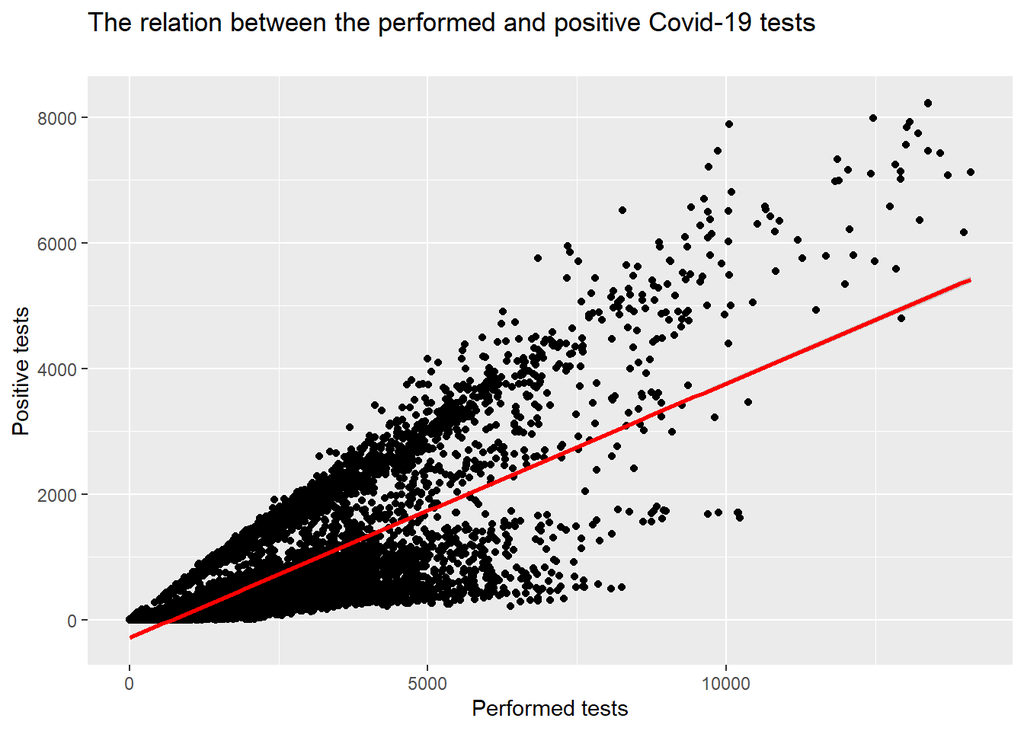

```r
cov_performed_tests_clean %>%
  ggplot(aes(x = Tested_with_result, y = Tested_positive)) +
  geom_point() +
  geom_smooth(method = "lm", color = "red") +
  labs(title = "The relation between the performed and positive Covid-19 tests\n", x = "Performed tests", y = "Positive tests")
```

A second one with using bin2d to get a clearer picture on the density of the data points. preventing overplotting if it occurs.

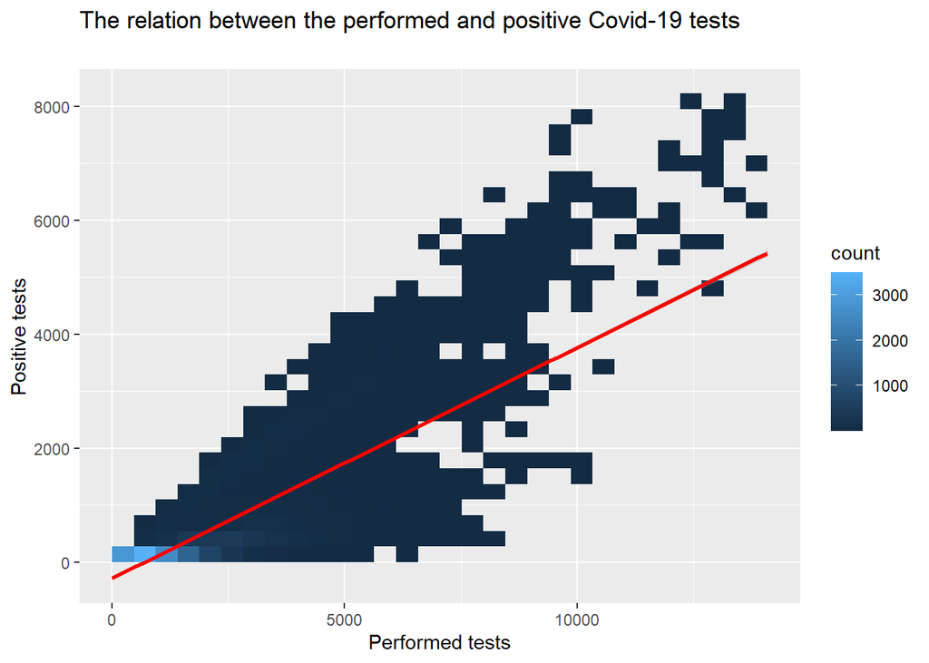

```r
cov_performed_tests_clean %>%
  ggplot(aes(x = Tested_with_result, y = Tested_positive)) +
  geom_bin2d() +
  geom_smooth(method = "lm", color = "red") +
  labs(title = "The relation between the performed and positive Covid-19 tests\n", x = "Performed tests", y = "Positive tests")
```

### Regression

In this regression the response variable is Tested_positive, Tested_with_result is the explanatory variable.

```r
summary(lm(Tested_positive~Tested_with_result, data = cov_performed_tests_clean))
```

```
##
## Call:
## lm(formula = Tested_positive ~ Tested_with_result, data = cov_performed_tests_clean)
##
## Residuals:
##     Min      1Q  Median      3Q     Max
## -2535.3  -211.7    -1.3   153.7  4104.6
##
## Coefficients:
##                       Estimate  Std. Error t value            Pr(>|t|)
## (Intercept)        -285.032275    5.463236  -52.17 <0.0000000000000002 ***
## Tested_with_result    0.405016    0.002306  175.63 <0.0000000000000002 ***
## ---
## Signif. codes:  0 '***' 0.001 '**' 0.01 '*' 0.05 '.' 0.1 ' ' 1
##
## Residual standard error: 486.5 on 17314 degrees of freedom
## Multiple R-squared:  0.6405, Adjusted R-squared:  0.6405
## F-statistic: 3.085e+04 on 1 and 17314 DF,  p-value: < 0.00000000000000022
```

### Explaining the coefficients

- Estimate:  
  The estimate in this regression is used to predict the outcome of the Tested_positive variable. In this instance given the intercept and slope of about -285.03 and 0.40 respectively you are able to calculate how many of the performed tests will be a positive test. e.g with 1000 performed tests the regression model predicts the amount of positive tests is around 115 using the formula (-285.03 + (0.40 * 1000)).
- Std. Error: The standard error shows the uncertainty of a given estimate in the coefficients the larger this value the less confident about the estimate. In this case the standard error for the variable Tested_with_result is 0.002306 meaning it can deviate 0.002306 on average.
- t value:  
  The t value is the estimate from the variable divided by the standard error. In this instance the t value given to Tested_with_result is 175.63
- Pr(>|t|):  
  The p-value corresponds to the t-statistic, the smaller the p-value, if the p-value is small that means that the given variable show a high statistical significance which is shown with the amount of asterisk. In this case in my regression the variable shows a p-value with a significance code of ’***’ meaning that the variable is probably a good addition to this model.
- Residual std error: The RSE shows the average difference between the shown outcome values and the predicted values by the model. The lower the RSE the better the model fits to the data. This regression shows an RSE of 486.5 which seems okay given the size of the dataset.
- Multiple R-squared:  
  The multiple R-squared shows how well the the data fits to the regression model and explains the variability in the model. In this case my multiple R-squared is 0.6405 which is pretty good given this is a dataset of the real world where it is usually expected it to be not really high.
- Adjusted R-squared: The adjusted R-squared usually changes when u add more than one variable to a model. in this case it stays the same at 0.6405 since this regression is only using one explanatory variable.

### Looking at the Residuals

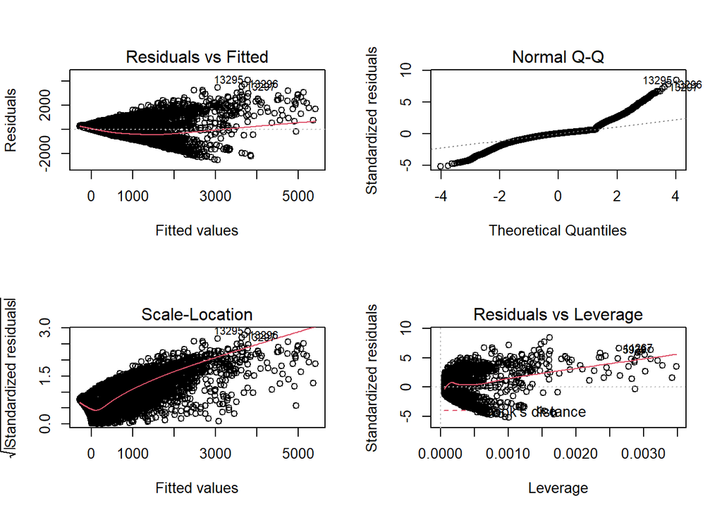

```r
par(mfrow=c(2,2))
plot(lm(Tested_positive~Tested_with_result, data = cov_performed_tests_clean))
```

### Conslusion about this regression

In general I think the regression is pretty good given the size of the dataset. Next time it might be smarter to choose a smaller subset of the population or a specific province since that might make the model also pass the homoscedasticity test.

## Regression Glenn

### Regression Goal

Find out the total deceased over total positive tests from Limburg

What I want to find out is the total deceased over the total positive tests from the province Limburg, because I originate from this province and found it interesting to find this out. For this, I will pick the COVID-19_numbers_municipality_per_day cleaned dataset (cov_general_data_clean)

### Explaining the used variables

- Deceased:  
  The variable that shows the total deceased that were tested positive of COVID-19.
- Total_reported:  
  The variable that shows the total positive tested reports of the province Limburg.
- Province:  
  The chosen province (Limburg).
- Date_of_publication:  
  Date of announcement to group the total deceased and total positive tests.

The variables come from the cov_general_data_clean tibble within the time frame from 2020-02-28 till 2022-03-30.

### Visualizing variables

Group the total positive reports and deceased from Limburg

```r
cov_general_data_lim <- cov_general_data_clean
cov_general_data_lim <- filter(cov_general_data_lim,Province=="Limburg")

total_deceased <- aggregate(cov_general_data_lim$Deceased, list(cov_general_data_lim$Date_of_publication), sum)
total_positive <- aggregate(cov_general_data_lim$Total_reported, list(cov_general_data_lim$Date_of_publication), sum)

names(total_deceased)[1] <- "Date_of_publication"
names(total_deceased)[2] <- "Deceased"
names(total_positive)[1] <- "Date_of_publication"
names(total_positive)[2] <- "Positive_tests"

finalReg <- merge(total_deceased, total_positive)
```

Making a simple plot to start visualizing the variables.

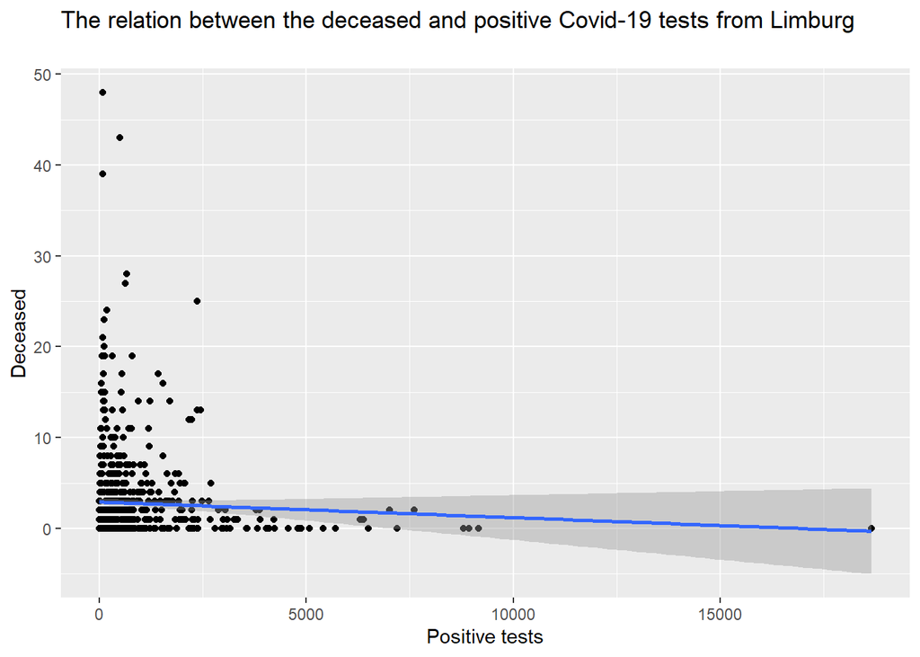

```r
finalReg %>%
  ggplot(aes(Positive_tests, Deceased)) +
  geom_point() +
  geom_smooth(method="lm") +
  labs(title = "The relation between the deceased and positive Covid-19 tests from Limburg\n", x = "Positive tests", y = "Deceased")
```

### Regression

In this regression the response variable is Deceased, Positive_tests is the explanatory variable.

```r
summary(lm(Deceased~Positive_tests, data=finalReg))
```

```
##
## Call:
## lm(formula = Deceased ~ Positive_tests, data = finalReg)
##
## Residuals:
##    Min     1Q Median     3Q    Max
## -2.930 -2.888 -1.864  0.341 45.086
##
## Coefficients:
##                  Estimate Std. Error t value            Pr(>|t|)
## (Intercept)     2.9298884  0.2003021   14.63 <0.0000000000000002 ***
## Positive_tests -0.0001729  0.0001331   -1.30               0.194
## ---
## Signif. codes:  0 '***' 0.001 '**' 0.01 '*' 0.05 '.' 0.1 ' ' 1
##
## Residual standard error: 4.933 on 760 degrees of freedom
## Multiple R-squared:  0.002218,   Adjusted R-squared:  0.0009047
## F-statistic: 1.689 on 1 and 760 DF,  p-value: 0.1941
```

### Explaining the coefficients

- Estimate: The estimate is used to predict the value of the response variable. In this case the estimate is 2.9298884 deceased when there is a total positive tests at 0. By each time a new positive tests is reported, the deceased variable increases with -0.0001729 deceased. This does not really make sense, because it would be very strange if we already confirm one or more deaths when we don’t have a positive test returned. In addition, the deceased count decreasing with -0.0001729 by every positive test also does not make much sense either, because then I can make a calculation of the deceased when there are 10000 positive tests returned (2.9298884 + (-0.0001729 * 10000)) = 1.2008884 deceased. If I had to think of a reason why the deceased decreases, then my only guess would be that more residents in Limburg were getting vaccinated per day during the lifespan of the dataset, but I hardly believe that this is the case.
- Std. Error: The standard error is a measure of the uncertainty in the estimate of the coefficient. In this case, the calculated deviation of the deceased variable is 0.2003021, and for the positive tests variable the deviation is 0.0001331. Which means that the std error of the deceased variable falls with 0.2003021 deceased from the regression line, and for the positive tests this is 0.0001331 positive tests.
- t value: This is the estimate from the variable divided by its standard error (Estimate / Std. Error). For the deceased this is 14.63 as the t value, where the positive tests is -1.30.
- Pr(>|t|): This gives a p-value for the t-test to determine if the coefficient is significant. From the deceased variable it shows a high statistic significance which is showed with three asterisks (Signif. code ***), being far below 0.05. For the positive tests variable, the statistic significance is very low since it doesn’t show a significance code, being above 0.1. With deceased being high, and positive tests being low, we cannot be confident that both variables create a systematic relationship, nor that it is very strong either.
- Residual std error: RSE is the average distance that the observed values fall from the regression line. The distance in this case is 4.933, which means that any prediction about the total deceased in Limburg would be off by 4.933 deceased. I think that this shows that the regression model doesn’t really fit the data, because it would be too many deceased that falls from the regression model.
- Multiple R-squared: This gives a measurement of what % of the variance in the response variable can be explained by the regression. In this case, the r-squared is too low to predict anything from the response variable (y as the deceased variable), which gives me more confidence that this regression model becomes not usable.
- Adjusted R-squared: The adjusted controls for each additional predictor added (to prevent overfitting), so it may not increase as you add more variables. Since the Multiple R-squared was very low, it would not make an exception for the adjusted R-squared to be low also.

### Looking at the Residuals

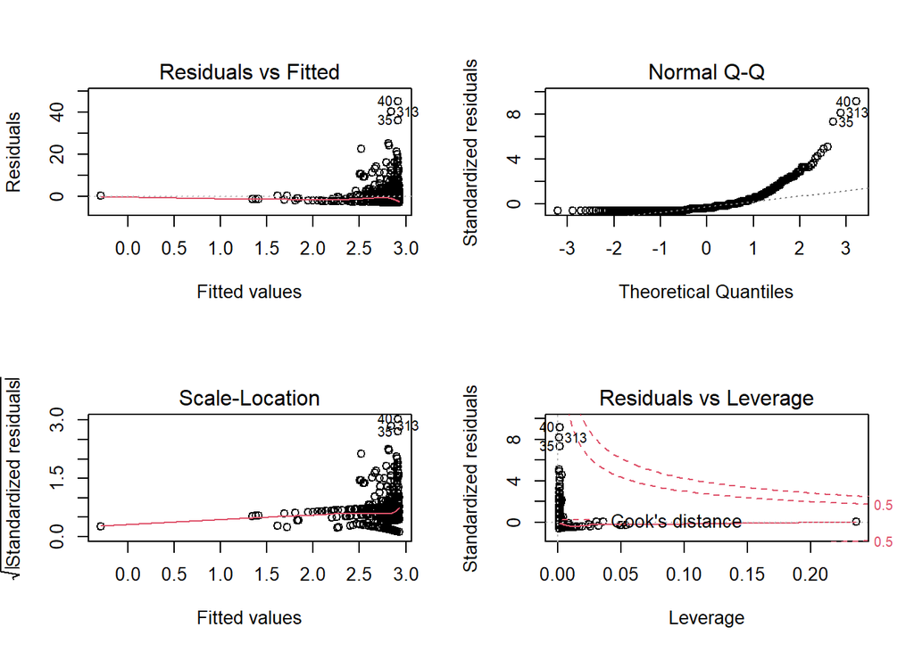

```r
par(mfrow=c(2,2))
plot(lm(Deceased~Positive_tests, data=finalReg))
```

- Residuals vs Fitted: As you can see with the plot that shows the residuals vs the fitted, the red line slightly deviates from the dotted line. For the red line, it means that the linearity assumption is met.
- Normal Q-Q: From the Q-Q plot the residuals hardly follow the dotted line in the plot, which makes it clear that the errors/residuals are not normally distributed. The normality assumption is not met.
- Scale-Location: The residuals in the Scale-Location plot do not show a constant variance at every level of x, instead of homoscedasticity, there is now the opposite: heteroscedasticity. This shows that the regression analysis becomes difficult to trust, it might have said earlier that a high statistic significance is present in the estimate variable, but this showcases that it might not be true.

### Conslusion about this regression

From my linear regression, regression model, and residual plots, I can see that this linear regression is not useful for my chosen dataset. The coefficients were too vague to predict a variable, as shown by the Estimate, the Residual Standard Error, and the Multiple R-Squared from the summary. In addition, the residual plots of the regression model also do not reflect the correct results of what a linear regression should show. And finally, the variables I used for it appear to be unrelated to the linear regression, meaning that the number of deceased from COVID-19 cannot be estimated from the number of positive tests alone. The positive tests on one publication date were sometimes larger than the other positive tests from a different publication date, which also means that there was inconsistency with the number of deceased on a publication date, there are many more factors behind this than just pulling out the positive tests to calculate the total number of deceased, the publication date as an example indicates a certain time/month when the results were recorded, which means that certain events might have happened during that time of the month causing the number of deceased and total positive tests to differ, such as holidays, adapted measures from a press conference, etc. In the end, the performed regression did not meet my goal and it turned out that this regression was not useful for the dataset.